# Trip Sequencing Part 1

Dave Hurst

Sunday, January 25, 2015

Here I am working to convert a trip into a sequence of segments. The input will be a full trip, and the output will be broken up into several components: - A list of segments, with details (or reference to details) on each segment - A sequence of segment ID’s that comprise the trip - A set data for each segment type

I’m going to try to reconstruct each trip out of segments made up of the following types:

- stops (no driver profile for these, but we need them to describe the segment)
- sharp turns
- curves (differentiated from sharp turns by radii (as a function of speed))
- bends ( differentiated from curves by time < 3 data points)
- straights
- uncategorized:
- - short straights (too short to collect profile info)
- - slow rolling sections (drive thrus, driveways, etc. – no profile info)
- - windy sections (ideally break these up later)
- - other?

Again starting with the familiar 2591/49 trip:

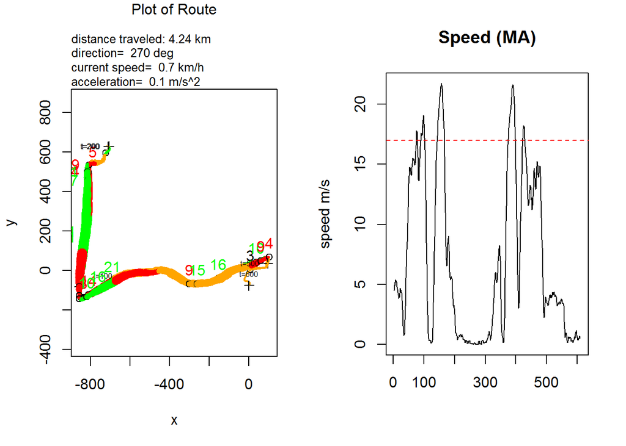

```r
driver.id <- 2591
trip.id <- 49
trip <- getTrip( driver.id, trip.id )

plotTripSegment(trip, 1, 99999)
```

## Stops and Rolls

Looking at the speed profile there look to be 3 stops during this trip. Since a stop sign or a drive thru could be a series of stops/slow rolls, and probably won’t impart anything in terms of driving style, let’s begin the stop segment anytime the speed drops below 1 m/s and continue it until we increases above a roll theshold (which I’ve arbitrarily set to 2 m/s after some emperical observations)

*NOTE: Tunable parameters -* Stop and Roll threshold speeds

I wrote a function to find all the stops in a trip based on that criteria. Here’s an example using the current trip followed by the code for the function.

```r
stops <- segment.parse.stops(trip, thresh.stop=1, thresh.roll=2)
stop.id <- 1:nrow(stops)
kable( cbind( stop.id, stops), format = "markdown")
```

| stop.id | t0 | tn |
| --- | --- | --- |
| 1 | 32 | 38 |
| 2 | 113 | 130 |
| 3 | 205 | 313 |
| 4 | 315 | 324 |
| 5 | 353 | 362 |
| 6 | 559 | 595 |
| 7 | 599 | 611 |

(t0 is the data point for the begin of the stop segment, and tn is the end)

```r
segment.parse.stops
```

```
## function (trip, tmin = 1, tmax = nrow(trip), thresh.stop = 1,
##     thresh.roll = 2, ma = 5)
## {
##     tmin <- max(1, tmin)
##     tmax <- min(tmax, nrow(trip))
##     stop <- data.frame(t0 = integer(), tn = integer())
##     t0 <- 1
##     thresh <- thresh.stop
##     stopped <- FALSE
##     for (t in tmin:tmax) {
##         vt <- trip[t, "v"]
##         if (stopped) {
##             if (vt > thresh.roll | t >= tmax) {
##                 stop.seg <- data.frame(t0 = t0, tn = t - 1)
##                 stop <- rbind(stop, stop.seg)
##                 stopped <- FALSE
##             }
##         }
##         else {
##             if (vt <= thresh.stop) {
##                 t0 <- t
##                 stopped <- TRUE
##             }
##         }
##     }
##     return(stop)
## }
```

When investigating these points, its useful to see use the PlotTripSegment function. Just remember to set MA=1 to negate the smoothing, since I’m not applying smoothing for the segmentation analysis. Here’s and example

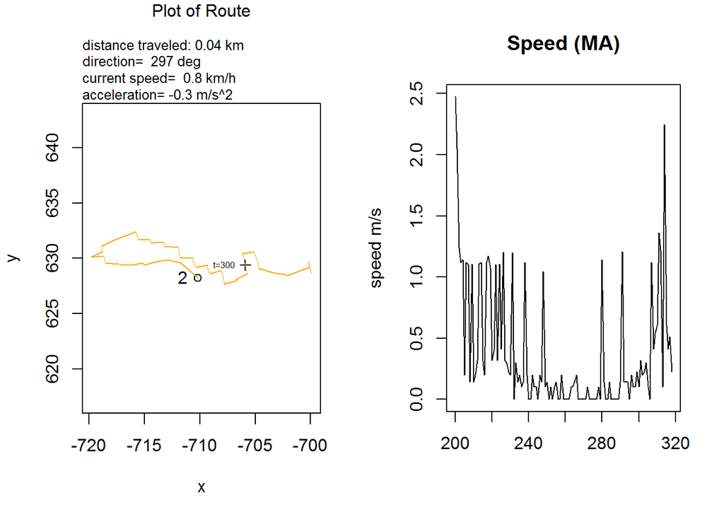

```r
stop <- stops[3,]
plotTripSegment(trip, stop$t0-5, stop$tn+5, ma=1)
```

I add 5 seconds to either side of the segment to see what’s going on with it. In this case, notice we head right back into a stop, which implies the threshold for ending the stop may be too low. I’ll experiment with that below.

Here’s an overlay of the trip plot with the location of each segment

```
##    t0  tn
## 1  32  38
## 2 113 130
## 3 205 313
## 4 315 324
## 5 353 362
## 6 559 595
## 7 599 611
```

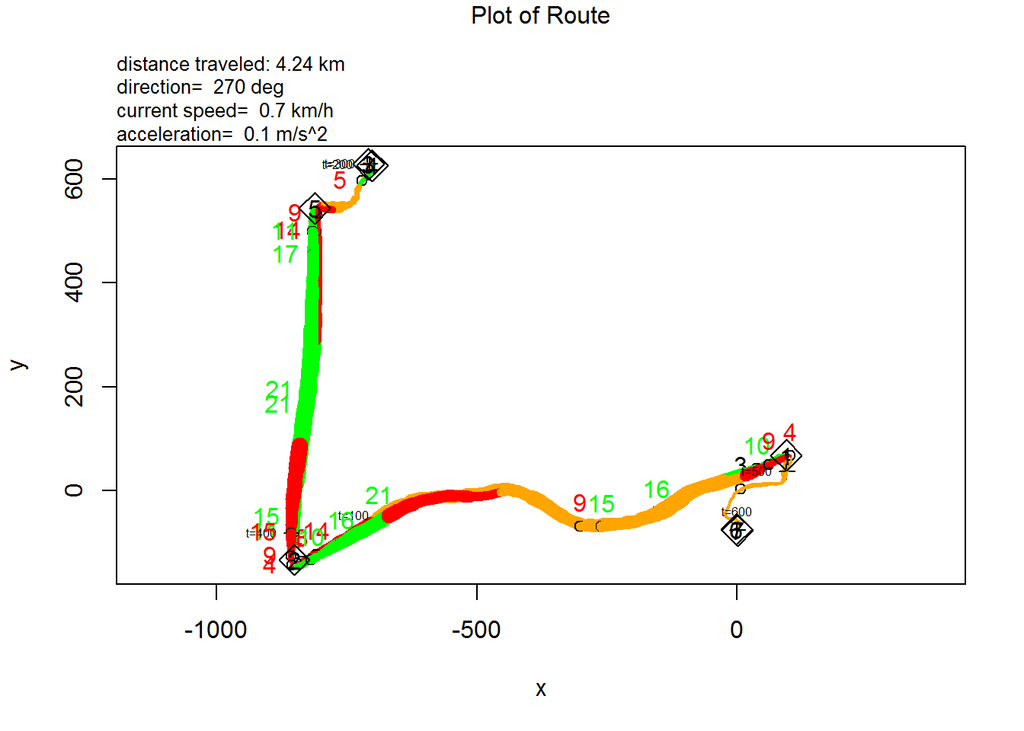

```r
plotTrip.stopOverlay <- function (d,t, ths=1, thr=2) {
    trip <- getTrip(d,t)
    stops <- segment.parse.stops(trip, thresh.stop=ths, thresh.roll=thr)
    print(stops)
    plotTrip(trip)
    for (i in 1:nrow(stops)) {
        t0 <- stops[i, "t0"]; tn <- stops[i, "tn"]
        loc.x <- mean( trip[c(t0,tn), "x"] )
        loc.y <- mean( trip[c(t0,tn), "y"] )
        points( loc.x, loc.y, pch = 5, cex=2)
        text( loc.x, loc.y, labels=i)
    }
}

plotTrip.stopOverlay(driver.id, trip.id)
```

Plot it again with a slightly higher roll threshold, and it looks cleaner.

```
##    t0  tn
## 1  32  38
## 2 113 130
## 3 205 324
## 4 353 363
## 5 559 611
```

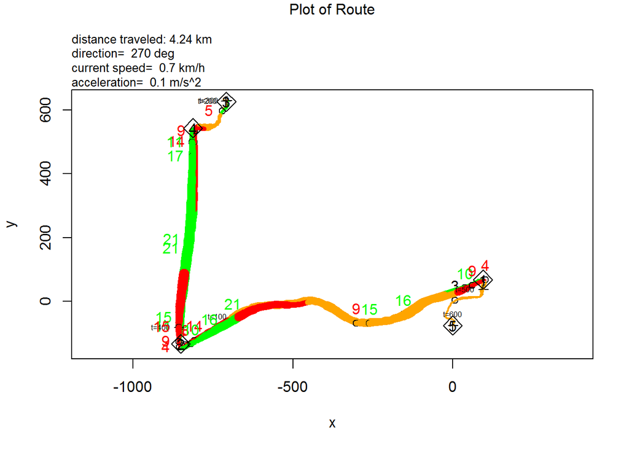

```r
plotTrip.stopOverlay(driver.id, trip.id, ths=1, thr=2.5)
```

And another for trip 150

```
##    t0  tn
## 1 231 233
## 2 759 760
## 3 773 829
```

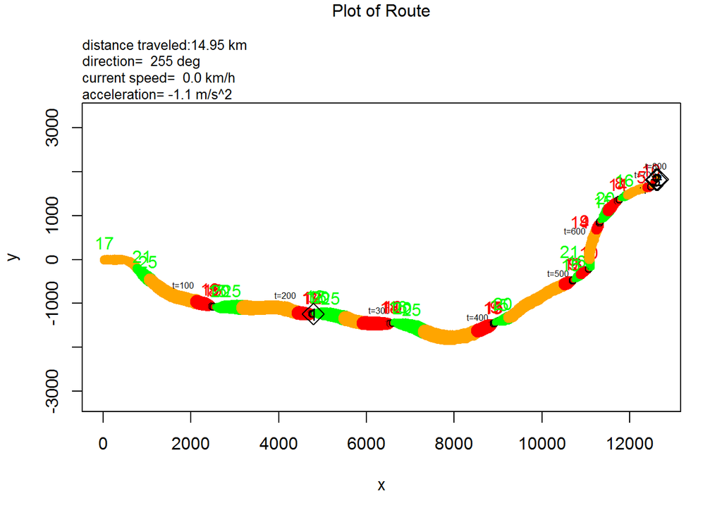

```r
plotTrip.stopOverlay(driver.id, 150, ths=1, thr=2)
```

Note here that stops 2 and 3 are right on top of each other in what appears to be a Uturn in the segment. So a little investigation is in order.

```r
trip.id <- 150
trip <- getTrip(driver.id, trip.id)
stops <- segment.parse.stops(trip, thresh.stop=1, thresh.roll=2)
print(stops)
```

```
##    t0  tn
## 1 231 233
## 2 759 760
## 3 773 829
```

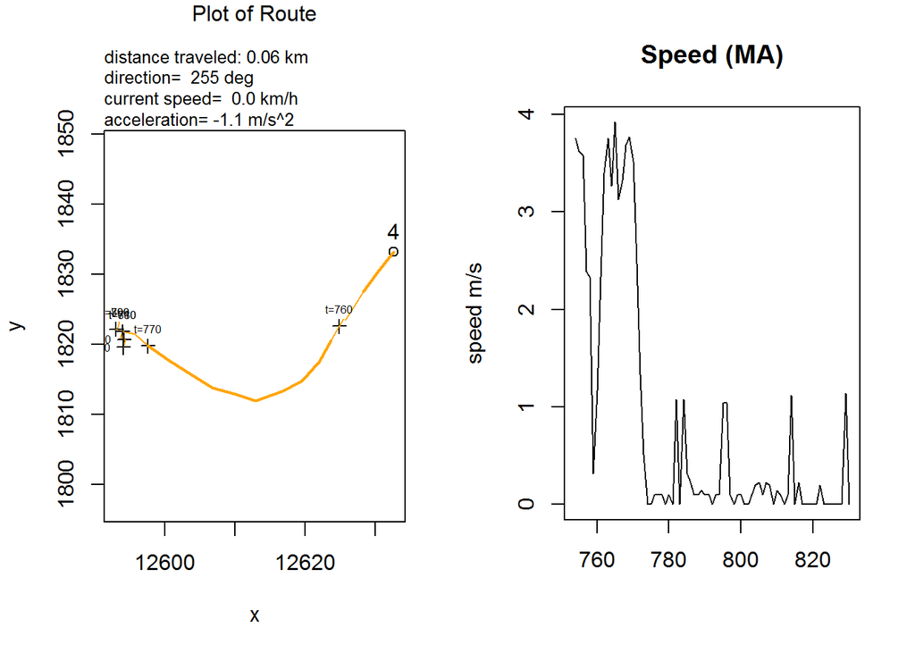

```r
plotTripSegment(trip, 754, 834 , ma=1, t.mark=10)
```

This shows a stop then a slow roll between 3 and 4 m/s, but that threshold is too high I think, so we’ll just have to live with the small segment in between (its about 25 m long).

a good stopping point.